# Trabajo 2

Rodrigo Reyes

2023-08-08

##Evaluación de 3 dietas (Normal, Control y Desafío) en cuánto a desempeño de SFR según los días de cultivo de cada grupo, esto, dentro de un ciclo completo de Salmo salar en la XI Región.

#Importa librerías de interés. Se instalaron paquetes readxl, ggplot2, dyplr, gridExtra, grid, kableExtra, tidyverse.

```r
library(readxl)
library(ggplot2)
library(dplyr)
library(gridExtra)
library(grid)
library(tidyverse)
library(e1071)
library(randomForest)
library(nnet)
Trabajo_personal_R_2 <- read_excel("Trabajo personal R_2.xlsx")
```

#Evaluación de variables La variable Peso tiene una desviación a la izquierda de los datos, concentrando mayores valores en el rango <1.000 gr.

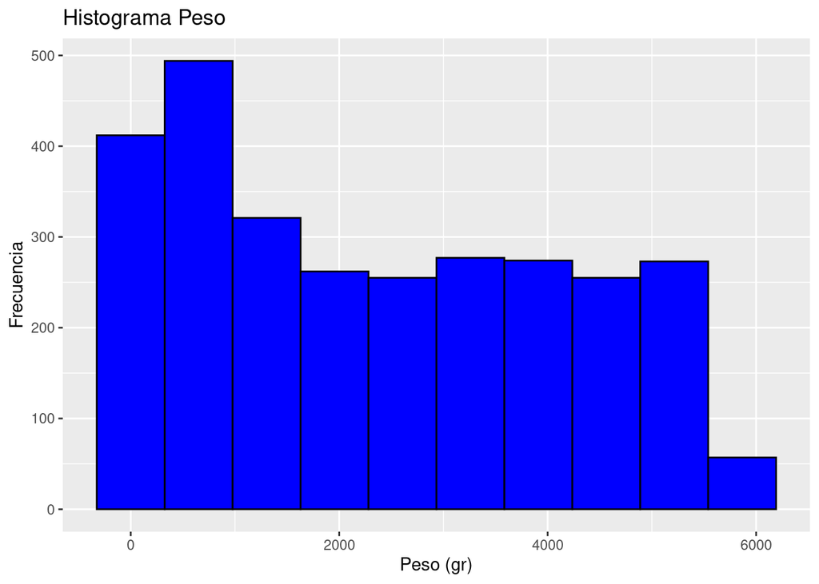

```r
ggplot(Trabajo_personal_R_2, aes(PESO))+
geom_histogram(color="black", fill="BLUE", bins = 10)+
labs(title="Histograma Peso", x="Peso (gr)",
y="Frecuencia") + theme_gray()
```

La variable SFR tiene una desviación a la izquierda de los datos, concentrando valores en 0,5 y 1%.

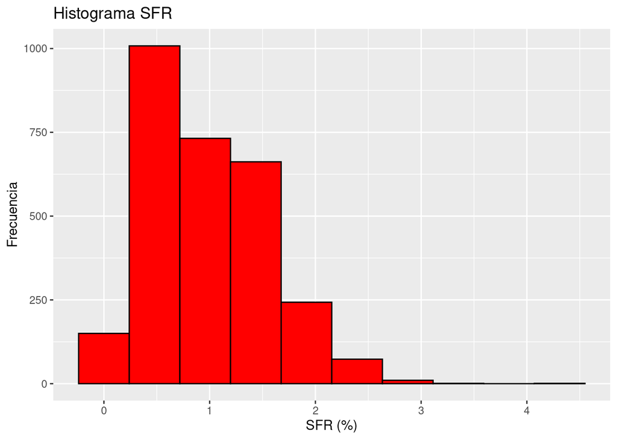

```r
ggplot(Trabajo_personal_R_2, aes(SFR))+
geom_histogram(color="black", fill="red", bins = 10)+
labs(title="Histograma SFR", x="SFR (%)",
y="Frecuencia") + theme_gray()
```

# Balance de datos

En base a este resultado, se evaluarán SFR por grupo de dieta. Considerando: Dieta Normal: Jaulas 101 a 104. Dieta Control: Jaulas 105 y 106. Dieta Desafío: Jaulas 107 y 108.

```r
Trabajo_personal_R <- read_excel("Trabajo personal R_2.xlsx")
table(Trabajo_personal_R$DIETA,Trabajo_personal_R$JAULA)
```

```
##
##           101 102 103 104 105 106 107 108
##   CONTROL   0   0   0   0 360 387   0   0
##   DESAFIO   0   0   0   0   0   0 383 382
##   NORMAL  315 328 348 377   0   0   0   0
```

# Relación entre variables cuantitativas

Se evalúa la distribución de la variable SFR agrupada durante todo el ciclo productivo de mar, con detalle por grupo de dieta y jaula.

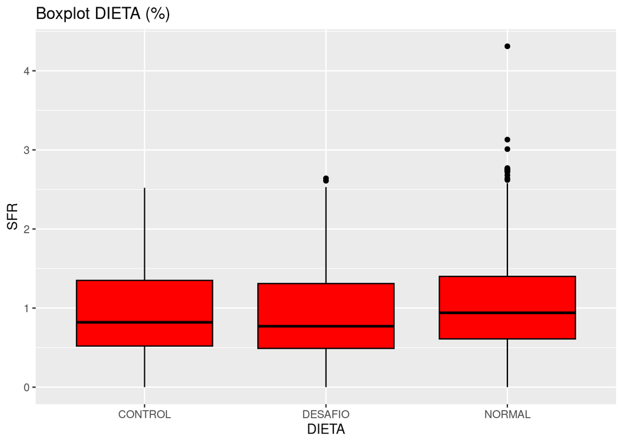

```r
ggplot(Trabajo_personal_R_2, aes(x=DIETA, y=SFR))+
geom_boxplot(color="black", fill="red")+
labs(title="Boxplot DIETA (%)", x="DIETA", y="SFR") + theme_gray()
```

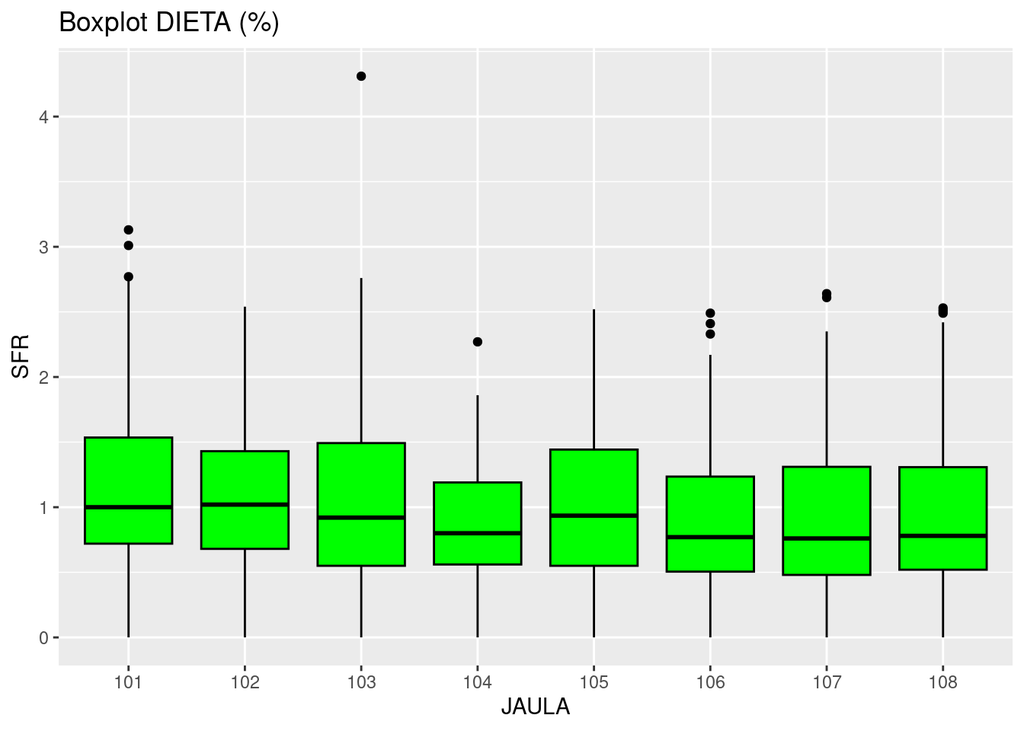

```r
ggplot(Trabajo_personal_R_2, aes(x=JAULA, y=SFR))+
geom_boxplot(color="black", fill="green")+
labs(title="Boxplot DIETA (%)", x="JAULA", y="SFR") + theme_gray()
```

# Revisión estructura de la información.

```r
str(Trabajo_personal_R_2)
```

```
## tibble [2,880 × 11] (S3: tbl_df/tbl/data.frame)
##  $ JAULA   : chr [1:2880] "101" "101" "101" "101" ...
##  $ DIETA   : chr [1:2880] "NORMAL" "NORMAL" "NORMAL" "NORMAL" ...
##  $ TTO     : chr [1:2880] NA NA NA NA ...
##  $ FECHA   : POSIXct[1:2880], format: "2021-08-08" "2021-08-09" ...
##  $ DIA     : num [1:2880] 1 2 3 4 5 6 7 8 9 10 ...
##  $ NUMERO  : num [1:2880] 100000 98924 98899 98877 98853 ...
##  $ PESO    : num [1:2880] 120 121 123 124 126 128 129 131 132 134 ...
##  $ ALIMENTO: num [1:2880] NA NA NA NA NA NA NA NA NA NA ...
##  $ SFR     : num [1:2880] 0 0.63 0.92 1.11 1.01 1.03 0.92 0.95 0.66 0.98 ...
##  $ MO      : num [1:2880] 1.08 0.03 0.02 0.02 0.04 0.1 0.05 0 0 0 ...
##  $ SRS     : num [1:2880] 0 0 0 0 0 0 0 0 0 0 ...
```

```r
summary(Trabajo_personal_R_2)
```

```
##     JAULA              DIETA               TTO
##  Length:2880        Length:2880        Length:2880
##  Class :character   Class :character   Class :character
##  Mode  :character   Mode  :character   Mode  :character
##
##
##
##
##      FECHA                          DIA             NUMERO            PESO
##  Min.   :2021-08-08 00:00:00   Min.   :  1.00   Min.   :  3015   Min.   : 120
##  1st Qu.:2021-11-14 00:00:00   1st Qu.: 90.75   1st Qu.: 93071   1st Qu.: 659
##  Median :2022-02-12 00:00:00   Median :180.50   Median : 97644   Median :2136
##  Mean   :2022-02-13 03:24:00   Mean   :181.41   Mean   : 93873   Mean   :2381
##  3rd Qu.:2022-05-13 00:00:00   3rd Qu.:270.25   3rd Qu.: 98794   3rd Qu.:3908
##  Max.   :2022-09-11 00:00:00   Max.   :387.00   Max.   :100000   Max.   :5986
##
##     ALIMENTO         SFR               MO               SRS
##  Min.   : 584   Min.   :0.0000   Min.   :0.00000   Min.   :0.000000
##  1st Qu.:1240   1st Qu.:0.5500   1st Qu.:0.00000   1st Qu.:0.000000
##  Median :1510   Median :0.8800   Median :0.01000   Median :0.000000
##  Mean   :1552   Mean   :0.9762   Mean   :0.02764   Mean   :0.008695
##  3rd Qu.:1837   3rd Qu.:1.3700   3rd Qu.:0.02000   3rd Qu.:0.003329
##  Max.   :2852   Max.   :4.3100   Max.   :1.28000   Max.   :0.547182
##  NA's   :2758
```

```r
dim(Trabajo_personal_R_2)
```

```
## [1] 2880   11
```

# Analisis exploratorio de datos

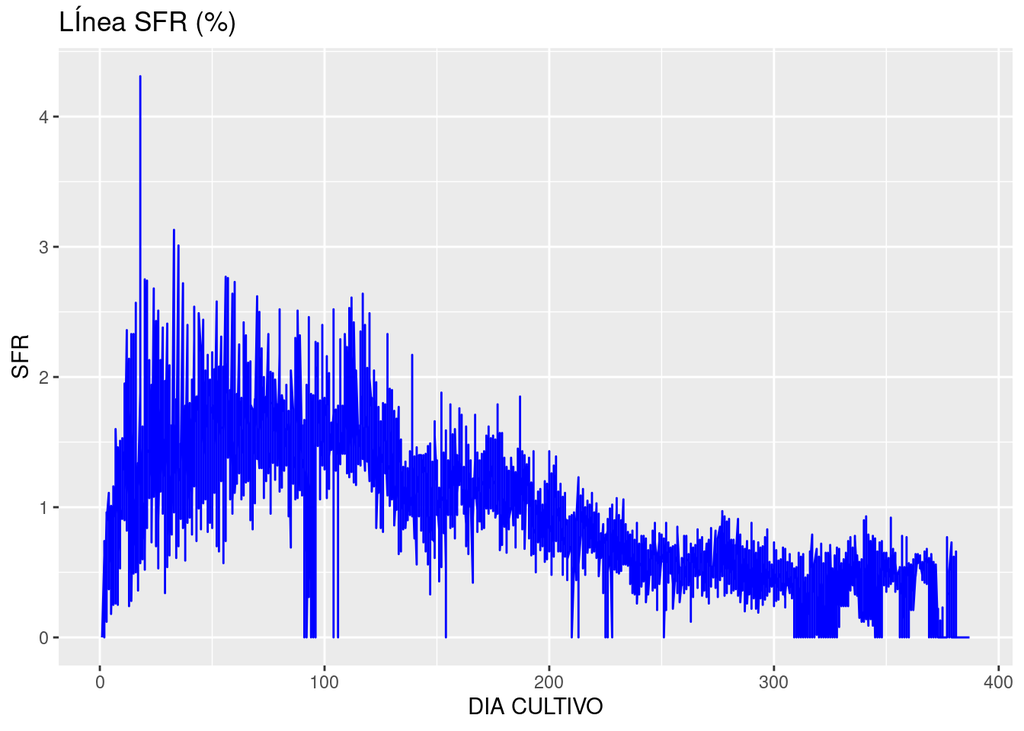

```r
ggplot(Trabajo_personal_R_2, aes(x=DIA, y=SFR))+
geom_line(color="blue", bins = 10)+
labs(title="LÍnea SFR (%)", x="DIA CULTIVO", y="SFR") + theme_gray()
```

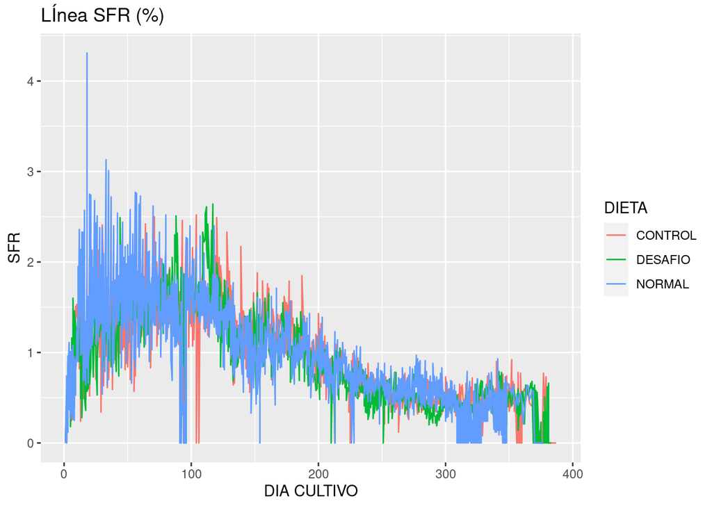

```r
ggplot(Trabajo_personal_R_2, aes(x=DIA, y=SFR, group =DIETA, colour = DIETA))+
geom_line()+
labs(title="LÍnea SFR (%)", x="DIA CULTIVO", y="SFR") +
theme_gray()
```

# Resumen de datos

Se evalua desempeño promedio, en SFR durante todo el ciclo productivo de mar, por jaula.

```r
Trabajo_personal_R_2 %>%
  group_by(JAULA, DIETA) %>%
  summarize(mean(NUMERO),mean(PESO), mean(SFR))
```

```
## # A tibble: 8 × 5
## # Groups:   JAULA [8]
##   JAULA DIETA   `mean(NUMERO)` `mean(PESO)` `mean(SFR)`
##   <chr> <chr>            <dbl>        <dbl>       <dbl>
## 1 101   NORMAL          94975.        2264.       1.15
## 2 102   NORMAL          96712.        2342.       1.08
## 3 103   NORMAL          88468.        2525.       1.03
## 4 104   NORMAL          97157.        2313.       0.867
## 5 105   CONTROL         96162.        2542.       1.03
## 6 106   CONTROL         95770.        2266.       0.871
## 7 107   DESAFIO         89675.        2413.       0.903
## 8 108   DESAFIO         92339.        2382.       0.921
```

```r
res.aov <- lm(SFR ~ DIETA, data = Trabajo_personal_R_2
              )
anova(res.aov)
```

```
## Analysis of Variance Table
##
## Response: SFR
##             Df Sum Sq Mean Sq F value    Pr(>F)
## DIETA        2   7.31  3.6563  11.892 7.187e-06 ***
## Residuals 2877 884.56  0.3075
## ---
## Signif. codes:  0 '***' 0.001 '**' 0.01 '*' 0.05 '.' 0.1 ' ' 1
```